# regression_report

```python
%load_ext autoreload
%autoreload 2

from dataclasses import dataclass, field
from math import sqrt
from pathlib import Path

import pandas as pd
from loguru import logger
from scipy.stats import randint, uniform
from sklearn.base import BaseEstimator
from sklearn.ensemble import RandomForestRegressor
from sklearn.feature_selection import SelectFromModel
from sklearn.linear_model import Lasso, Ridge
from sklearn.metrics import (
    explained_variance_score,
    mean_absolute_error,
    mean_squared_error,
    r2_score,
)
from sklearn.model_selection import (
    RandomizedSearchCV,
    cross_val_score,
    train_test_split,
)
from sklearn.neighbors import KNeighborsRegressor
from sklearn.pipeline import Pipeline, make_pipeline
from sklearn.preprocessing import RobustScaler
from sklearn.svm import SVR
from xgboost import XGBRegressor

from matplotlib import pyplot as plt
```

## Wine quality regression problem

### Dataset description

This dataset includes various chemical properties of wines, along with some synthetic features created for analysis or teaching purposes. Below is a description of each variable:

- `id`: Unique identifier for each wine sample.
- `alcohol`: Alcohol content of the wine, measured in % volume.
- `chlorides`: Chloride content of the wine, measured in grams of salt per liter.
- `citric acid`: Citric Acid content of the wine, measured in grams per liter. Citric acid is a weak organic acid that can be used as a natural preservative.
- `density`: Density of the wine, measured in g/cm³. This can be an indicator of alcohol and sugar content.
- `feat01` to `feat10`: Synthetic variables created by a teacher for analysis or teaching purposes. These may represent derived or transformed features based on the original dataset, but their exact meaning is not specified.
- `fixed acidity`: Fixed acidity of the wine, measured in grams of tartaric acid per liter. It refers to the non-volatile acids that do not evaporate easily.
- `free sulfur dioxide`: Free sulfur dioxide content of the wine, measured in mg per liter. Sulfur dioxide is used as an antioxidant and antimicrobial agent in winemaking.
- `pH`: pH level of the wine, indicating its acidity or basicity on a scale from 0 to 14.
- `quality`: Quality rating of the wine, which could be based on sensory data or expert opinions.
- `residual sugar`: Residual sugar content of the wine, measured in grams per liter. This is the sugar remaining after fermentation.
- `sulphates`: Sulphate content of the wine, measured in grams of potassium sulphate per liter. Sulphates can influence the fermentation process and the wine's flavor.
- `total sulfur dioxide`: Total sulfur dioxide content of the wine, measured in mg per liter. It includes both free and bound forms of SO2.
- `volatile acidity`: Volatile acidity of the wine, measured in grams of acetic acid per liter. It refers to the steam-distillable acids present in wine.

```python
pd.set_option("display.max_columns", None)
```

```python
import pandas as pd
from pathlib import Path
data_path = Path.cwd() / "data" / "r2.csv"
df = pd.read_csv(data_path)
y_col = "quality"
x_cols = [col for col in df.columns if col not in [y_col, "id"]]
```

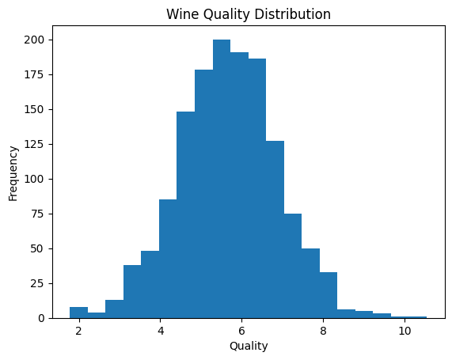

```python
df[y_col].plot(kind="hist", bins=20, title="Wine Quality Distribution", xlabel="Quality")
```

The histogram shows that the distribution of wine quality ratings is roughly bell-shaped, suggesting a normal distribution, with most wines having a quality rating around the middle of the scale. There are very few wines with very low or very high quality ratings (2, 3, 9, and 10). The most common ratings appear to be between 5 and 7. There is a peak at a quality rating of 6, which suggests that this is the most common rating given to wines in this dataset.

This type of distribution is typical for quality ratings, where extreme values (very high or very low quality) are less common than moderate values. It implies that while there are outliers of exceptional and poor quality, most wines are considered to be of average quality. This could be useful for winemakers or retailers to understand the quality distribution of wines and to benchmark new wines against this distribution.

```python
df
```

|  | id | alcohol | chlorides | citric acid | density | feat01 | feat02 | feat03 | feat04 | feat05 | feat06 | feat07 | feat08 | feat09 | feat10 | fixed acidity | free sulfur dioxide | pH | quality | residual sugar | sulphates | total sulfur dioxide | volatile acidity |
| --- | --- | --- | --- | --- | --- | --- | --- | --- | --- | --- | --- | --- | --- | --- | --- | --- | --- | --- | --- | --- | --- | --- | --- |
| 0 | 1 | 9.6 | 0.081 | 0.44 | 0.98920 | 0.777174 | 0.101811 | 0.615949 | 0.335220 | 0.072921 | 0.550654 | 0.321462 | 0.742844 | 0.120581 | 0.762964 | 9.7 | 23.0 | 3.49 | 4.248582 | 2.2 | 4.63 | 67.0 | 0.600 |
| 1 | 2 | 11.9 | 0.074 | 0.01 | 1.00371 | 0.682378 | 0.702689 | 0.595187 | 0.738317 | 0.079608 | 0.360016 | 0.668480 | 0.158404 | 0.377644 | 0.704609 | 7.9 | 33.0 | 3.44 | 6.365523 | 2.0 | 4.57 | 41.0 | 0.725 |
| 2 | 3 | 9.6 | 0.084 | 0.49 | 1.00870 | 0.477076 | 0.491814 | 0.123014 | 0.491648 | 0.112396 | 0.113222 | 0.413835 | 0.388120 | 0.513607 | 0.334223 | 9.2 | 23.0 | 3.38 | 5.094680 | 2.5 | 4.57 | 75.0 | 0.470 |
| 3 | 4 | 11.0 | 0.081 | 0.33 | 1.00490 | 0.745925 | 0.741657 | 0.769887 | 0.298042 | 0.167762 | 0.503632 | 0.839153 | 0.101733 | 0.157231 | 0.746054 | 7.1 | 24.0 | 3.44 | 5.903533 | 2.1 | 4.75 | 36.0 | 0.410 |
| 4 | 5 | 9.4 | 0.080 | 0.24 | 0.99620 | 0.729406 | 0.606721 | 0.425811 | 0.276605 | 0.944117 | 0.583265 | 0.542587 | 0.015201 | 0.796945 | 0.733268 | 7.8 | 6.0 | 3.31 | 6.267095 | 1.7 | 4.59 | 12.0 | 0.420 |
| ... | ... | ... | ... | ... | ... | ... | ... | ... | ... | ... | ... | ... | ... | ... | ... | ... | ... | ... | ... | ... | ... | ... | ... |
| 1395 | 1396 | 10.4 | 0.082 | 0.35 | 0.99798 | 0.192436 | 0.723544 | 0.199929 | 0.430688 | 0.967864 | 0.333939 | 0.500769 | 0.650995 | 0.409950 | 0.017794 | 10.7 | 26.0 | 3.24 | 6.535230 | 3.2 | 4.69 | 69.0 | 0.420 |
| 1396 | 1397 | 9.4 | 0.095 | 0.44 | 0.99708 | 0.704294 | 0.039272 | 0.161863 | 0.314071 | 0.774961 | 0.370215 | 0.480095 | 0.372677 | 0.517385 | 0.452004 | 9.5 | 11.0 | 3.31 | 4.568697 | 1.8 | 4.55 | 23.0 | 0.430 |
| 1397 | 1398 | 10.1 | 0.094 | 0.19 | 1.00787 | 0.882430 | 0.440148 | 0.837819 | 0.569797 | 0.357397 | 0.964399 | 0.281663 | 0.283731 | 0.553142 | 0.463633 | 9.0 | 32.0 | 3.25 | 7.242271 | 3.9 | 4.50 | 71.0 | 0.600 |
| 1398 | 1399 | 9.3 | 0.062 | 0.15 | 1.00550 | 0.545192 | 0.776621 | 0.897308 | 0.493320 | 0.982628 | 0.743984 | 0.453231 | 0.145450 | 0.573566 | 0.566089 | 6.3 | 8.0 | 3.45 | 5.288451 | 1.7 | 4.57 | 21.0 | 0.380 |
| 1399 | 1400 | 10.2 | 0.068 | 0.30 | 1.00914 | 0.701931 | 0.939797 | 0.939678 | 0.410566 | 0.818064 | 0.056838 | 0.269703 | 0.767881 | 0.031286 | 0.678998 | 7.2 | 22.0 | 3.33 | 3.640250 | 4.4 | 5.17 | 111.0 | 0.600 |

1400 rows × 23 columns

```python
df.dtypes
```

```
id                        int64
alcohol                 float64
chlorides               float64
citric acid             float64
density                 float64
feat01                  float64
feat02                  float64
feat03                  float64
feat04                  float64
feat05                  float64
feat06                  float64
feat07                  float64
feat08                  float64
feat09                  float64
feat10                  float64
fixed acidity           float64
free sulfur dioxide     float64
pH                      float64
quality                 float64
residual sugar          float64
sulphates               float64
total sulfur dioxide    float64
volatile acidity        float64
dtype: object
```

```python
df.isna().sum()
```

```
id                      0
alcohol                 0
chlorides               0
citric acid             0
density                 0
feat01                  0
feat02                  0
feat03                  0
feat04                  0
feat05                  0
feat06                  0
feat07                  0
feat08                  0
feat09                  0
feat10                  0
fixed acidity           0
free sulfur dioxide     0
pH                      0
quality                 0
residual sugar          0
sulphates               0
total sulfur dioxide    0
volatile acidity        0
dtype: int64
```

We can see that all of the variables have numerical types, and there are no missing values in the dataset. This means that we can proceed directly to the next step of the analysis, which is to split the data into training and testing sets.

```python
from sklearn.model_selection import train_test_split
x, x_out_of_sample, y, y_out_of_sample = train_test_split(
    df[x_cols], df[y_col], test_size=0.2, random_state=42
)
```

# Description of Hyperparameter Optimization Code

The code snippet is written in Python and utilizes `scikit-learn`'s powerful classes and functions for preprocessing data, constructing machine learning pipelines, and performing hyperparameter optimization.

## Key Components

### Hyperparameter Optimization Execution

- `run_hyperopt_one_model`: This function takes a dataset and a `HyperoptInput` object and runs randomized search cross-validation to find the best hyperparameters for the model.
- `run_hyperopt`: This function runs `run_hyperopt_one_model` for a list of models and hyperparameter spaces.

```python
@dataclass
class HyperoptInput:
    model: BaseEstimator
    hyperopt_space: dict[str, any] = field(default_factory=dict)


def get_pipeline_for_model(
    model: BaseEstimator, model_params: dict[str, any] | None = None
):
    return Pipeline(
        [
            ("scaler", RobustScaler()),
            (
                "feature_selection",
                SelectFromModel(XGBRegressor(), threshold="0.5*median"),
            ),
            ("model", model(**model_params if model_params else {})),
        ]
    )
```

```python
base_hyperopt_inputs = [
    HyperoptInput(
        model=RandomForestRegressor,
        hyperopt_space={
            "model__n_jobs": [-1],
            "model__n_estimators": randint(100, 500),
            "model__max_depth": randint(3, 10),
            "model__min_samples_split": uniform(0.01, 0.1),
            "model__min_samples_leaf": uniform(0.01, 0.1),
        },
    ),
    HyperoptInput(
        model=XGBRegressor,
        hyperopt_space={
            "model__n_jobs": [-1],
            "model__n_estimators": randint(50, 500),
            "model__max_depth": randint(3, 10),
            "model__learning_rate": uniform(0.01, 0.3),
            "model__subsample": uniform(0.5, 0.5),
            "model__colsample_bytree": uniform(0.5, 0.5),
            "model__gamma": uniform(0, 5),
        },
    ),
    HyperoptInput(
        model=Ridge, hyperopt_space={"model__alpha": uniform(0.1, 100)}
    ),
    HyperoptInput(
        model=Lasso, hyperopt_space={"model__alpha": uniform(0.0001, 1.0)}
    ),
    HyperoptInput(
        model=SVR,
        hyperopt_space={
            "model__C": uniform(0.1, 10),
            "model__gamma": ["scale", "auto"],
            "model__epsilon": uniform(0.01, 0.1),
        },
    ),
    HyperoptInput(
        model=KNeighborsRegressor,
        hyperopt_space={
            "model__n_neighbors": randint(3, 30),
            "model__weights": ["uniform", "distance"],
            "model__p": [
                1,
                2,
            ],  # 1 is Manhattan distance, 2 is Euclidean distance
        },
    ),
]
```

```python
@dataclass
class OneModelHyperoptResult:
    best_model: BaseEstimator
    best_score: float
    cv_results: pd.DataFrame

    def get_model_name(self) -> str:
        return self.best_model["model"].__class__.__name__


@dataclass
class HyperoptResults:
    results: list[OneModelHyperoptResult]

    def __post_init__(self):
        self._sort_by_best_score()

    def _sort_by_best_score(self, reversed: bool = True):
        self.results.sort(key=lambda x: x.best_score, reverse=reversed)

    def get_best_model(self):
        return self.results[0].best_model

    def get_n_best_models(self, n: int):
        return [result.best_model for result in self.results[:n]]

    def get_best_score(self):
        return self.results[0].best_score

    def get_merged_df(self):
        results = pd.DataFrame()
        for result in self.results:
            results = pd.concat(
                [
                    results,
                    result.cv_results.assign(
                        model_name=result.get_model_name()
                    ),
                ],
                axis=0,
            )

        return results

    def get_all_dfs(self):
        return [
            (result.get_model_name(), result.cv_results)
            for result in self.results
        ]

    def get_all_scores(self):
        return [
            (result.get_model_name(), result.best_score)
            for result in self.results
        ]

    def get_all_models(self):
        return [
            (result.get_model_name(), result.best_model)
            for result in self.results
        ]


def run_hyperopt_one_model(
    x: pd.DataFrame,
    y: pd.Series,
    model_input: HyperoptInput,
    n_iter: int = 10,
    cv: int = 5,
    random_state: int = 42,
):
    pipeline = get_pipeline_for_model(model_input.model)
    search = RandomizedSearchCV(
        pipeline,
        model_input.hyperopt_space,
        n_iter=n_iter,
        scoring="neg_root_mean_squared_error",
        n_jobs=-1,
        cv=cv,
        random_state=random_state,
    )
    search.fit(x, y)
    return OneModelHyperoptResult(
        best_model=search.best_estimator_,
        best_score=search.best_score_,
        cv_results=pd.DataFrame(search.cv_results_),
    )
```

```python
def run_hyperopt(
    hyperopt_inputs=base_hyperopt_inputs,
    n_iter: int = 10,
    cv: int = 5,
    random_state: int = 42,
) -> HyperoptResults:
    results = []
    for model_input in hyperopt_inputs:
        logger.info(f"Running hyperopt for {model_input.model.__name__}")
        result = run_hyperopt_one_model(
            x=x,
            y=y,
            model_input=model_input,
            n_iter=n_iter,
            cv=cv,
            random_state=random_state,
        )
        results.append(result)
        logger.info(f"Best score: {result.best_score}")
    return HyperoptResults(results=results)
```

```python
results = run_hyperopt()
```

```
2024-01-21 23:06:01.804 | INFO     | __main__:run_hyperopt:9 - Running hyperopt for RandomForestRegressor
2024-01-21 23:06:14.148 | INFO     | __main__:run_hyperopt:19 - Best score: -1.063872334462141
2024-01-21 23:06:14.149 | INFO     | __main__:run_hyperopt:9 - Running hyperopt for XGBRegressor
2024-01-21 23:06:18.707 | INFO     | __main__:run_hyperopt:19 - Best score: -1.044570102807818
2024-01-21 23:06:18.707 | INFO     | __main__:run_hyperopt:9 - Running hyperopt for Ridge
2024-01-21 23:06:20.839 | INFO     | __main__:run_hyperopt:19 - Best score: -1.0554349671339018
2024-01-21 23:06:20.885 | INFO     | __main__:run_hyperopt:9 - Running hyperopt for Lasso
2024-01-21 23:06:23.193 | INFO     | __main__:run_hyperopt:19 - Best score: -1.0692471470244878
2024-01-21 23:06:23.194 | INFO     | __main__:run_hyperopt:9 - Running hyperopt for SVR
2024-01-21 23:06:25.792 | INFO     | __main__:run_hyperopt:19 - Best score: -1.0674628872883367
2024-01-21 23:06:25.793 | INFO     | __main__:run_hyperopt:9 - Running hyperopt for KNeighborsRegressor
2024-01-21 23:06:27.936 | INFO     | __main__:run_hyperopt:19 - Best score: -1.1072753707966632
```

```python
results.get_all_scores()
```

```
[('XGBRegressor', -1.044570102807818),
 ('Ridge', -1.0554349671339018),
 ('RandomForestRegressor', -1.063872334462141),
 ('SVR', -1.0674628872883367),
 ('Lasso', -1.0692471470244878),
 ('KNeighborsRegressor', -1.1072753707966632)]
```

The negative root mean squared error (neg_root_mean_squared_error) metric is indicative of the average magnitude of error in the predictions made by the regression models, with lower values (closer to zero) representing better performance. The use of k-fold cross-validation ensures that each model's score is the mean of the results from multiple test sets, providing a more robust assessment of the model's predictive ability. The XGBRegressor model achieved the highest mean score across the test folds, suggesting it has the best predictive accuracy with the lowest average error among the evaluated models.

```python
best_model = results.get_best_model()
best_model
```

```
Pipeline(steps=[('scaler', RobustScaler()),
                ('feature_selection',
                 SelectFromModel(estimator=XGBRegressor(base_score=None,
                                                        booster=None,
                                                        callbacks=None,
                                                        colsample_bylevel=None,
                                                        colsample_bynode=None,
                                                        colsample_bytree=None,
                                                        device=None,
                                                        early_stopping_rounds=None,
                                                        enable_categorical=False,
                                                        eval_metric=None,
                                                        feature_types=None,
                                                        gamma=None,
                                                        grow_policy=None,
                                                        importanc...
                              grow_policy=None, importance_type=None,
                              interaction_constraints=None,
                              learning_rate=0.013979488347959958, max_bin=None,
                              max_cat_threshold=None, max_cat_to_onehot=None,
                              max_delta_step=None, max_depth=3, max_leaves=None,
                              min_child_weight=None, missing=nan,
                              monotone_constraints=None, multi_strategy=None,
                              n_estimators=365, n_jobs=-1,
                              num_parallel_tree=None, random_state=None, ...))])
```

```python
best_models = results.get_n_best_models(5)
```

```python
@dataclass
class RegressionScores:
    model_name: str
    mean_squared_error: float
    mean_absolute_error: float
    root_mean_squared_error: float

def calculate_regression_scores(
    model: BaseEstimator, X_test: pd.DataFrame, y_test: pd.Series
) -> RegressionScores:
    y_pred = model.predict(X_test)
    y_pred = [
        max(0, min(pred, 10)) for pred in y_pred
    ]  # ensure that we don't have negative or >10 predictions
    mse = mean_squared_error(y_test, y_pred)
    mae = mean_absolute_error(y_test, y_pred)
    rmse = sqrt(mse)

    return RegressionScores(
        model_name=model["model"].__class__.__name__,
        mean_squared_error=mse,
        mean_absolute_error=mae,
        root_mean_squared_error=rmse,
    )
```

```python
best_model_scores = calculate_regression_scores(
    best_model, x_out_of_sample, y_out_of_sample
)
best_model_scores
# Best model basing on metric on kfold cross validation
```

```
RegressionScores(model_name='XGBRegressor', mean_squared_error=1.36515466797506, mean_absolute_error=0.8952051777187162, root_mean_squared_error=1.1683983344626352)
```

```python
best_models_scores = [
    calculate_regression_scores(model, x_out_of_sample, y_out_of_sample)
    for model in best_models
]
best_models_scores
best_models_scores_df = pd.DataFrame(
    best_models_scores, index=[model.__class__.__name__ for model in best_models]
).sort_values("root_mean_squared_error").round(3)
best_models_scores_df
```

|  | model_name | mean_squared_error | mean_absolute_error | root_mean_squared_error |
| --- | --- | --- | --- | --- |
| Pipeline | RandomForestRegressor | 1.340 | 0.880 | 1.157 |
| Pipeline | XGBRegressor | 1.365 | 0.895 | 1.168 |
| Pipeline | SVR | 1.383 | 0.910 | 1.176 |
| Pipeline | Lasso | 1.404 | 0.915 | 1.185 |
| Pipeline | Ridge | 1.415 | 0.914 | 1.190 |

The provided data shows performance metrics for various regression models on an out-of-sample dataset, typically a validation or test set. These metrics are used to evaluate the accuracy of the models' predictions:

**RandomForestRegressor**: This model has the lowest mean squared error (MSE) and root mean squared error (RMSE) of 1.340 and 1.157, respectively, indicating it has the most accurate predictions with the least amount of error among the models listed. Its mean absolute error (MAE) is also the lowest at 0.880, suggesting it has the smallest average deviation from the actual values.

**XGBRegressor**: With an MSE of 1.365 and an RMSE of 1.168, the XGBRegressor is slightly less accurate than the RandomForestRegressor. The MAE is 0.895, which is marginally higher, indicating slightly larger average errors in its predictions.

**SVR**, **Lasso**, and **Ridge**: These models exhibit a progressive increase in MSE and RMSE, indicating a decrease in predictive accuracy compared to the RandomForest and XGBoost models. The SVR has an RMSE of 1.176, Lasso has an RMSE of 1.185, and Ridge has the highest RMSE of 1.190. Their MAEs are quite similar, ranging from 0.910 to 0.915, meaning their average prediction errors are comparable.

In summary, the RandomForestRegressor model is the best performer on the out-of-sample data in terms of all three metrics, which signifies it may be the most reliable model for predicting unseen data in this particular scenario. The other models show incrementally higher errors, with the Ridge model having the highest error rates according to these metrics.

```python
best_models_scores_train = [
    calculate_regression_scores(model, x, y)
    for model in best_models
]
best_models_scores_train
best_models_scores_df_trian = pd.DataFrame(
    best_models_scores_train, index=[model.__class__.__name__ for model in best_models]
).sort_values("root_mean_squared_error").round(3)
best_models_scores_df_trian
```

|  | model_name | mean_squared_error | mean_absolute_error | root_mean_squared_error |
| --- | --- | --- | --- | --- |
| Pipeline | RandomForestRegressor | 0.707 | 0.669 | 0.841 |
| Pipeline | XGBRegressor | 0.753 | 0.702 | 0.868 |
| Pipeline | SVR | 1.000 | 0.777 | 1.000 |
| Pipeline | Ridge | 1.079 | 0.830 | 1.039 |
| Pipeline | Lasso | 1.121 | 0.845 | 1.059 |

The performance metrics for the regression models on the training dataset, which was used for hyperparameter optimization with cross-validation (CV), are presented here:

**RandomForestRegressor**: This model exhibits the best performance on the training set, with the lowest mean squared error (MSE) of 0.707 and the lowest root mean squared error (RMSE) of 0.841. Its mean absolute error (MAE) is also the smallest at 0.669, indicating that on average, its predictions are closest to the actual values.

**XGBRegressor**: The XGBRegressor shows slightly less accuracy on the training data compared to the RandomForestRegressor, with a MSE of 0.753 and an RMSE of 0.868. Its MAE is 0.702, which is higher than the RandomForestRegressor, suggesting that its predictions are, on average, less accurate.

**SVR**, **Ridge**, and **Lasso**: These models have progressively higher MSE and RMSE values, indicating lower accuracy on the training set. The SVR has an RMSE of 1.000, making it the baseline against which the other models are compared (since it's equal to 1). Ridge and Lasso have even higher errors, with RMSEs of 1.039 and 1.059, respectively, and their MAEs are also higher, indicating larger average prediction errors.

From this data, we can infer that the RandomForestRegressor not only performs best on the out-of-sample data but also shows the highest accuracy during the training phase. This consistency in performance suggests that the RandomForestRegressor model is likely to generalize well to new, unseen data. The higher errors in the training phase for models such as Ridge and Lasso might also indicate that they are less prone to overfitting to the training data compared to the RandomForestRegressor, but this requires additional context on the complexity of the models and the nature of the dataset to confirm.

```python
results.get_merged_df()
```

|  | mean_fit_time | std_fit_time | mean_score_time | std_score_time | param_model__colsample_bytree | param_model__gamma | param_model__learning_rate | param_model__max_depth | param_model__n_estimators | param_model__n_jobs | param_model__subsample | params | split0_test_score | split1_test_score | split2_test_score | split3_test_score | split4_test_score | mean_test_score | std_test_score | rank_test_score | model_name | param_model__alpha | param_model__min_samples_leaf | param_model__min_samples_split | param_model__C | param_model__epsilon | param_model__n_neighbors | param_model__p | param_model__weights |
| --- | --- | --- | --- | --- | --- | --- | --- | --- | --- | --- | --- | --- | --- | --- | --- | --- | --- | --- | --- | --- | --- | --- | --- | --- | --- | --- | --- | --- | --- |
| 0 | 0.235349 | 0.026645 | 0.002859 | 0.002345 | 0.68727 | 4.753572 | 0.229598 | 7 | 70 | -1 | 0.578009 | {'model__colsample_bytree': 0.6872700594236812... | -1.167810 | -1.131749 | -1.088761 | -1.075842 | -1.159164 | -1.124665 | 0.036809 | 9 | XGBRegressor | NaN | NaN | NaN | NaN | NaN | NaN | NaN | NaN |
| 1 | 0.320096 | 0.032632 | 0.002603 | 0.000979 | 0.577997 | 0.290418 | 0.269853 | 6 | 409 | -1 | 0.854036 | {'model__colsample_bytree': 0.5779972601681014... | -1.191152 | -1.101002 | -1.151351 | -1.112768 | -1.201978 | -1.151650 | 0.040424 | 10 | XGBRegressor | NaN | NaN | NaN | NaN | NaN | NaN | NaN | NaN |
| 2 | 0.321968 | 0.011695 | 0.001932 | 0.000393 | 0.510292 | 4.849549 | 0.259733 | 8 | 435 | -1 | 0.590912 | {'model__colsample_bytree': 0.5102922471479012... | -1.104905 | -1.103584 | -1.076270 | -1.106367 | -1.207748 | -1.119775 | 0.045376 | 8 | XGBRegressor | NaN | NaN | NaN | NaN | NaN | NaN | NaN | NaN |
| 3 | 0.288585 | 0.029518 | 0.001972 | 0.000191 | 0.591702 | 1.521211 | 0.167427 | 6 | 394 | -1 | 0.645615 | {'model__colsample_bytree': 0.5917022549267169... | -1.163602 | -1.095527 | -1.053442 | -1.094114 | -1.165794 | -1.114496 | 0.043694 | 7 | XGBRegressor | NaN | NaN | NaN | NaN | NaN | NaN | NaN | NaN |
| 4 | 0.398880 | 0.022359 | 0.002979 | 0.001573 | 0.805926 | 0.697469 | 0.097643 | 9 | 239 | -1 | 0.545303 | {'model__colsample_bytree': 0.8059264473611898... | -1.117959 | -1.060828 | -1.044260 | -1.028875 | -1.157861 | -1.081957 | 0.048461 | 4 | XGBRegressor | NaN | NaN | NaN | NaN | NaN | NaN | NaN | NaN |
| 5 | 0.247234 | 0.009829 | 0.002373 | 0.001430 | 0.809193 | 1.91231 | 0.304969 | 3 | 180 | -1 | 0.92997 | {'model__colsample_bytree': 0.8091930046665436... | -1.087326 | -1.065396 | -1.102594 | -1.053806 | -1.211429 | -1.104110 | 0.056268 | 6 | XGBRegressor | NaN | NaN | NaN | NaN | NaN | NaN | NaN | NaN |
| 6 | 0.360129 | 0.025295 | 0.001988 | 0.000023 | 0.840154 | 2.252496 | 0.013979 | 3 | 365 | -1 | 0.781644 | {'model__colsample_bytree': 0.8401537692938899... | -1.061231 | -1.036653 | -1.007458 | -1.009193 | -1.108315 | -1.044570 | 0.037503 | 1 | XGBRegressor | NaN | NaN | NaN | NaN | NaN | NaN | NaN | NaN |
| 7 | 0.491650 | 0.080416 | 0.002119 | 0.000056 | 0.692708 | 0.079831 | 0.079268 | 6 | 416 | -1 | 0.841632 | {'model__colsample_bytree': 0.692708251269958,... | -1.128034 | -1.078495 | -1.065067 | -1.055379 | -1.166236 | -1.098642 | 0.042042 | 5 | XGBRegressor | NaN | NaN | NaN | NaN | NaN | NaN | NaN | NaN |
| 8 | 0.290419 | 0.014380 | 0.001853 | 0.000039 | 0.804998 | 4.165975 | 0.062009 | 3 | 469 | -1 | 0.591118 | {'model__colsample_bytree': 0.8049983288913105... | -1.098308 | -1.036571 | -1.018584 | -1.005914 | -1.114813 | -1.054838 | 0.043654 | 2 | XGBRegressor | NaN | NaN | NaN | NaN | NaN | NaN | NaN | NaN |
| 9 | 0.309330 | 0.029154 | 0.002024 | 0.000063 | 0.877681 | 2.125779 | 0.072382 | 6 | 359 | -1 | 0.515657 | {'model__colsample_bytree': 0.8776807051588262... | -1.117044 | -1.068844 | -1.034952 | -1.048080 | -1.137696 | -1.081323 | 0.039661 | 3 | XGBRegressor | NaN | NaN | NaN | NaN | NaN | NaN | NaN | NaN |
| 0 | 0.204544 | 0.006523 | 0.001195 | 0.000035 | NaN | NaN | NaN | NaN | NaN | NaN | NaN | {'model__alpha': 37.55401188473625} | -1.064747 | -1.041811 | -1.012347 | -1.022671 | -1.135599 | -1.055435 | 0.043883 | 1 | Ridge | 37.554012 | NaN | NaN | NaN | NaN | NaN | NaN | NaN |
| 1 | 0.201385 | 0.016197 | 0.001318 | 0.000309 | NaN | NaN | NaN | NaN | NaN | NaN | NaN | {'model__alpha': 95.17143064099162} | -1.070379 | -1.044235 | -1.015738 | -1.022111 | -1.134513 | -1.057395 | 0.043056 | 10 | Ridge | 95.171431 | NaN | NaN | NaN | NaN | NaN | NaN | NaN |
| 2 | 0.200129 | 0.017553 | 0.001485 | 0.000661 | NaN | NaN | NaN | NaN | NaN | NaN | NaN | {'model__alpha': 73.2993941811405} | -1.068158 | -1.043000 | -1.014116 | -1.021864 | -1.134765 | -1.056381 | 0.043450 | 8 | Ridge | 73.299394 | NaN | NaN | NaN | NaN | NaN | NaN | NaN |
| 3 | 0.214692 | 0.010373 | 0.002190 | 0.002034 | NaN | NaN | NaN | NaN | NaN | NaN | NaN | {'model__alpha': 59.96584841970366} | -1.066843 | -1.042411 | -1.013298 | -1.021957 | -1.135009 | -1.055903 | 0.043651 | 5 | Ridge | 59.965848 | NaN | NaN | NaN | NaN | NaN | NaN | NaN |
| 4 | 0.196364 | 0.015041 | 0.001150 | 0.000014 | NaN | NaN | NaN | NaN | NaN | NaN | NaN | {'model__alpha': 15.701864044243651} | -1.062943 | -1.041909 | -1.012197 | -1.024322 | -1.136436 | -1.055561 | 0.043904 | 2 | Ridge | 15.701864 | NaN | NaN | NaN | NaN | NaN | NaN | NaN |
| 5 | 0.214253 | 0.019147 | 0.002213 | 0.001549 | NaN | NaN | NaN | NaN | NaN | NaN | NaN | {'model__alpha': 15.699452033620265} | -1.062943 | -1.041909 | -1.012197 | -1.024323 | -1.136436 | -1.055561 | 0.043904 | 3 | Ridge | 15.699452 | NaN | NaN | NaN | NaN | NaN | NaN | NaN |
| 6 | 0.195688 | 0.021523 | 0.001161 | 0.000025 | NaN | NaN | NaN | NaN | NaN | NaN | NaN | {'model__alpha': 5.908361216819946} | -1.062265 | -1.042267 | -1.012516 | -1.025498 | -1.136914 | -1.055892 | 0.043809 | 4 | Ridge | 5.908361 | NaN | NaN | NaN | NaN | NaN | NaN | NaN |
| 7 | 0.220055 | 0.010376 | 0.001145 | 0.000015 | NaN | NaN | NaN | NaN | NaN | NaN | NaN | {'model__alpha': 86.7176145774935} | -1.069514 | -1.043724 | -1.015076 | -1.021965 | -1.134590 | -1.056974 | 0.043216 | 9 | Ridge | 86.717615 | NaN | NaN | NaN | NaN | NaN | NaN | NaN |
| 8 | 0.210165 | 0.026122 | 0.001881 | 0.001500 | NaN | NaN | NaN | NaN | NaN | NaN | NaN | {'model__alpha': 60.21150117432088} | -1.066867 | -1.042420 | -1.013312 | -1.021953 | -1.135004 | -1.055911 | 0.043647 | 6 | Ridge | 60.211501 | NaN | NaN | NaN | NaN | NaN | NaN | NaN |
| 9 | 0.175444 | 0.011889 | 0.001084 | 0.000049 | NaN | NaN | NaN | NaN | NaN | NaN | NaN | {'model__alpha': 70.90725777960455} | -1.067920 | -1.042884 | -1.013958 | -1.021866 | -1.134803 | -1.056286 | 0.043489 | 7 | Ridge | 70.907258 | NaN | NaN | NaN | NaN | NaN | NaN | NaN |
| 0 | 0.634896 | 0.083376 | 0.055966 | 0.021253 | NaN | NaN | NaN | 9 | 171 | -1 | NaN | {'model__max_depth': 9, 'model__min_samples_le... | -1.122730 | -1.079652 | -1.055898 | -1.091282 | -1.152418 | -1.100396 | 0.033760 | 9 | RandomForestRegressor | NaN | 0.089654 | 0.028343 | NaN | NaN | NaN | NaN | NaN |
| 1 | 1.065374 | 0.108261 | 0.056870 | 0.011193 | NaN | NaN | NaN | 7 | 314 | -1 | NaN | {'model__max_depth': 7, 'model__min_samples_le... | -1.112138 | -1.066077 | -1.046477 | -1.076601 | -1.144534 | -1.089165 | 0.034947 | 8 | RandomForestRegressor | NaN | 0.069685 | 0.054583 | NaN | NaN | NaN | NaN | NaN |
| 2 | 1.673183 | 0.168335 | 0.078684 | 0.023836 | NaN | NaN | NaN | 5 | 459 | -1 | NaN | {'model__max_depth': 5, 'model__min_samples_le... | -1.109594 | -1.056156 | -1.042261 | -1.068832 | -1.132233 | -1.081815 | 0.033779 | 7 | RandomForestRegressor | NaN | 0.055925 | 0.043371 | NaN | NaN | NaN | NaN | NaN |
| 3 | 1.508178 | 0.094830 | 0.058781 | 0.004103 | NaN | NaN | NaN | 5 | 393 | -1 | NaN | {'model__max_depth': 5, 'model__min_samples_le... | -1.101033 | -1.045572 | -1.037692 | -1.062439 | -1.128303 | -1.075008 | 0.034452 | 6 | RandomForestRegressor | NaN | 0.012058 | 0.106991 | NaN | NaN | NaN | NaN | NaN |
| 4 | 1.520670 | 0.140439 | 0.079982 | 0.014038 | NaN | NaN | NaN | 4 | 413 | -1 | NaN | {'model__max_depth': 4, 'model__min_samples_le... | -1.104790 | -1.044249 | -1.031580 | -1.059073 | -1.124396 | -1.072818 | 0.035744 | 5 | RandomForestRegressor | NaN | 0.028182 | 0.02834 | NaN | NaN | NaN | NaN | NaN |
| 5 | 0.971996 | 0.110087 | 0.035443 | 0.005971 | NaN | NaN | NaN | 8 | 158 | -1 | NaN | {'model__max_depth': 8, 'model__min_samples_le... | -1.108936 | -1.023258 | -1.018177 | -1.045106 | -1.123885 | -1.063872 | 0.044095 | 1 | RandomForestRegressor | NaN | 0.010707 | 0.012306 | NaN | NaN | NaN | NaN | NaN |
| 6 | 1.791283 | 0.160275 | 0.057204 | 0.005294 | NaN | NaN | NaN | 9 | 370 | -1 | NaN | {'model__max_depth': 9, 'model__min_samples_le... | -1.106340 | -1.033166 | -1.023673 | -1.048074 | -1.121810 | -1.066613 | 0.039828 | 2 | RandomForestRegressor | NaN | 0.023949 | 0.039214 | NaN | NaN | NaN | NaN | NaN |
| 7 | 1.904382 | 0.091070 | 0.081837 | 0.009972 | NaN | NaN | NaN | 8 | 463 | -1 | NaN | {'model__max_depth': 8, 'model__min_samples_le... | -1.100590 | -1.035375 | -1.028597 | -1.054590 | -1.125076 | -1.068845 | 0.037717 | 4 | RandomForestRegressor | NaN | 0.019061 | 0.071839 | NaN | NaN | NaN | NaN | NaN |
| 8 | 1.238122 | 0.108570 | 0.049874 | 0.005309 | NaN | NaN | NaN | 9 | 406 | -1 | NaN | {'model__max_depth': 9, 'model__min_samples_le... | -1.130930 | -1.097373 | -1.071986 | -1.097952 | -1.161571 | -1.111963 | 0.031074 | 10 | RandomForestRegressor | NaN | 0.108323 | 0.056676 | NaN | NaN | NaN | NaN | NaN |
| 9 | 1.434220 | 0.188568 | 0.059529 | 0.018260 | NaN | NaN | NaN | 9 | 487 | -1 | NaN | {'model__max_depth': 9, 'model__min_samples_le... | -1.105506 | -1.035431 | -1.026742 | -1.053207 | -1.122254 | -1.068628 | 0.038289 | 3 | RandomForestRegressor | NaN | 0.027052 | 0.016505 | NaN | NaN | NaN | NaN | NaN |
| 0 | 0.324307 | 0.032539 | 0.010431 | 0.003423 | NaN | scale | NaN | NaN | NaN | NaN | NaN | {'model__C': 3.845401188473625, 'model__epsilo... | -1.129941 | -1.108680 | -1.083348 | -1.037457 | -1.151422 | -1.102170 | 0.039450 | 5 | SVR | NaN | NaN | NaN | 3.845401 | 0.105071 | NaN | NaN | NaN |
| 1 | 0.270604 | 0.019570 | 0.008603 | 0.000220 | NaN | auto | NaN | NaN | NaN | NaN | NaN | {'model__C': 7.896910002727692, 'model__epsilo... | -1.163022 | -1.155255 | -1.099390 | -1.068418 | -1.172402 | -1.131698 | 0.040598 | 8 | SVR | NaN | NaN | NaN | 7.89691 | 0.069685 | NaN | NaN | NaN |
| 2 | 0.240748 | 0.011989 | 0.009824 | 0.001371 | NaN | auto | NaN | NaN | NaN | NaN | NaN | {'model__C': 1.6599452033620266, 'model__epsil... | -1.104968 | -1.089267 | -1.032132 | -1.030907 | -1.144187 | -1.080292 | 0.043658 | 3 | SVR | NaN | NaN | NaN | 1.659945 | 0.015808 | NaN | NaN | NaN |
| 3 | 0.244093 | 0.016061 | 0.009144 | 0.000630 | NaN | scale | NaN | NaN | NaN | NaN | NaN | {'model__C': 3.4370861113902182, 'model__epsil... | -1.133162 | -1.114691 | -1.083725 | -1.039151 | -1.152474 | -1.104641 | 0.039822 | 6 | SVR | NaN | NaN | NaN | 3.437086 | 0.024287 | NaN | NaN | NaN |
| 4 | 0.230481 | 0.009208 | 0.010452 | 0.004388 | NaN | auto | NaN | NaN | NaN | NaN | NaN | {'model__C': 0.30584494295802445, 'model__epsi... | -1.077375 | -1.078700 | -1.011120 | -1.030574 | -1.139545 | -1.067463 | 0.044622 | 1 | SVR | NaN | NaN | NaN | 0.305845 | 0.106991 | NaN | NaN | NaN |
| 5 | 0.263012 | 0.015316 | 0.008868 | 0.000186 | NaN | auto | NaN | NaN | NaN | NaN | NaN | {'model__C': 9.485527090157502, 'model__epsilo... | -1.184475 | -1.173676 | -1.118898 | -1.088607 | -1.183181 | -1.149767 | 0.038952 | 10 | SVR | NaN | NaN | NaN | 9.485527 | 0.010078 | NaN | NaN | NaN |
| 6 | 0.242312 | 0.009298 | 0.009125 | 0.000686 | NaN | auto | NaN | NaN | NaN | NaN | NaN | {'model__C': 1.9340450985343383, 'model__epsil... | -1.106417 | -1.093359 | -1.035270 | -1.028954 | -1.142108 | -1.081221 | 0.043204 | 4 | SVR | NaN | NaN | NaN | 1.934045 | 0.040424 | NaN | NaN | NaN |
| 7 | 0.229457 | 0.016967 | 0.009317 | 0.000813 | NaN | scale | NaN | NaN | NaN | NaN | NaN | {'model__C': 0.17066305219717406, 'model__epsi... | -1.087852 | -1.087555 | -1.030517 | -1.044048 | -1.144171 | -1.078829 | 0.039927 | 2 | SVR | NaN | NaN | NaN | 0.170663 | 0.012306 | NaN | NaN | NaN |
| 8 | 0.249341 | 0.009888 | 0.009061 | 0.000262 | NaN | auto | NaN | NaN | NaN | NaN | NaN | {'model__C': 6.218528947223795, 'model__epsilo... | -1.156639 | -1.139519 | -1.088972 | -1.060008 | -1.164318 | -1.121891 | 0.040574 | 7 | SVR | NaN | NaN | NaN | 6.218529 | 0.023949 | NaN | NaN | NaN |
| 9 | 0.231494 | 0.026358 | 0.008513 | 0.000101 | NaN | auto | NaN | NaN | NaN | NaN | NaN | {'model__C': 9.83755518841459, 'model__epsilon... | -1.184121 | -1.174177 | -1.117411 | -1.086076 | -1.183830 | -1.149123 | 0.040094 | 9 | SVR | NaN | NaN | NaN | 9.837555 | 0.033277 | NaN | NaN | NaN |
| 0 | 0.280026 | 0.028142 | 0.001186 | 0.000074 | NaN | NaN | NaN | NaN | NaN | NaN | NaN | {'model__alpha': 0.3746401188473625} | -1.239197 | -1.221437 | -1.201059 | -1.204366 | -1.251121 | -1.223436 | 0.019407 | 4 | Lasso | 0.37464 | NaN | NaN | NaN | NaN | NaN | NaN | NaN |
| 1 | 0.235500 | 0.033289 | 0.002045 | 0.001067 | NaN | NaN | NaN | NaN | NaN | NaN | NaN | {'model__alpha': 0.9508143064099162} | -1.239197 | -1.221437 | -1.201059 | -1.204366 | -1.251121 | -1.223436 | 0.019407 | 4 | Lasso | 0.950814 | NaN | NaN | NaN | NaN | NaN | NaN | NaN |
| 2 | 0.207504 | 0.013201 | 0.001154 | 0.000016 | NaN | NaN | NaN | NaN | NaN | NaN | NaN | {'model__alpha': 0.7320939418114051} | -1.239197 | -1.221437 | -1.201059 | -1.204366 | -1.251121 | -1.223436 | 0.019407 | 4 | Lasso | 0.732094 | NaN | NaN | NaN | NaN | NaN | NaN | NaN |
| 3 | 0.198957 | 0.017949 | 0.001147 | 0.000015 | NaN | NaN | NaN | NaN | NaN | NaN | NaN | {'model__alpha': 0.5987584841970366} | -1.239197 | -1.221437 | -1.201059 | -1.204366 | -1.251121 | -1.223436 | 0.019407 | 4 | Lasso | 0.598758 | NaN | NaN | NaN | NaN | NaN | NaN | NaN |
| 4 | 0.214446 | 0.021433 | 0.001142 | 0.000010 | NaN | NaN | NaN | NaN | NaN | NaN | NaN | {'model__alpha': 0.1561186404424365} | -1.143927 | -1.132298 | -1.104547 | -1.107472 | -1.179027 | -1.133455 | 0.027198 | 3 | Lasso | 0.156119 | NaN | NaN | NaN | NaN | NaN | NaN | NaN |
| 5 | 0.210702 | 0.022144 | 0.001160 | 0.000039 | NaN | NaN | NaN | NaN | NaN | NaN | NaN | {'model__alpha': 0.15609452033620264} | -1.143907 | -1.132275 | -1.104523 | -1.107446 | -1.179014 | -1.133433 | 0.027202 | 2 | Lasso | 0.156095 | NaN | NaN | NaN | NaN | NaN | NaN | NaN |
| 6 | 0.195434 | 0.007082 | 0.001760 | 0.001224 | NaN | NaN | NaN | NaN | NaN | NaN | NaN | {'model__alpha': 0.058183612168199464} | -1.081393 | -1.056819 | -1.033654 | -1.030881 | -1.143489 | -1.069247 | 0.041358 | 1 | Lasso | 0.058184 | NaN | NaN | NaN | NaN | NaN | NaN | NaN |
| 7 | 0.208193 | 0.033376 | 0.001612 | 0.000951 | NaN | NaN | NaN | NaN | NaN | NaN | NaN | {'model__alpha': 0.8662761457749352} | -1.239197 | -1.221437 | -1.201059 | -1.204366 | -1.251121 | -1.223436 | 0.019407 | 4 | Lasso | 0.866276 | NaN | NaN | NaN | NaN | NaN | NaN | NaN |
| 8 | 0.188023 | 0.010253 | 0.001441 | 0.000540 | NaN | NaN | NaN | NaN | NaN | NaN | NaN | {'model__alpha': 0.6012150117432088} | -1.239197 | -1.221437 | -1.201059 | -1.204366 | -1.251121 | -1.223436 | 0.019407 | 4 | Lasso | 0.601215 | NaN | NaN | NaN | NaN | NaN | NaN | NaN |
| 9 | 0.183642 | 0.021962 | 0.001176 | 0.000130 | NaN | NaN | NaN | NaN | NaN | NaN | NaN | {'model__alpha': 0.7081725777960455} | -1.239197 | -1.221437 | -1.201059 | -1.204366 | -1.251121 | -1.223436 | 0.019407 | 4 | Lasso | 0.708173 | NaN | NaN | NaN | NaN | NaN | NaN | NaN |
| 0 | 0.194681 | 0.020207 | 0.024325 | 0.003152 | NaN | NaN | NaN | NaN | NaN | NaN | NaN | {'model__n_neighbors': 9, 'model__p': 2, 'mode... | -1.173254 | -1.131093 | -1.123143 | -1.103754 | -1.185071 | -1.143263 | 0.030858 | 6 | KNeighborsRegressor | NaN | NaN | NaN | NaN | NaN | 9 | 2 | uniform |
| 1 | 0.193076 | 0.005325 | 0.016681 | 0.008758 | NaN | NaN | NaN | NaN | NaN | NaN | NaN | {'model__n_neighbors': 17, 'model__p': 1, 'mod... | -1.146263 | -1.077481 | -1.099266 | -1.074072 | -1.152379 | -1.109892 | 0.033390 | 3 | KNeighborsRegressor | NaN | NaN | NaN | NaN | NaN | 17 | 1 | distance |
| 2 | 0.205668 | 0.011696 | 0.007236 | 0.001705 | NaN | NaN | NaN | NaN | NaN | NaN | NaN | {'model__n_neighbors': 23, 'model__p': 1, 'mod... | -1.144802 | -1.076101 | -1.091290 | -1.081368 | -1.142816 | -1.107275 | 0.030232 | 1 | KNeighborsRegressor | NaN | NaN | NaN | NaN | NaN | 23 | 1 | distance |
| 3 | 0.205294 | 0.016928 | 0.006848 | 0.003055 | NaN | NaN | NaN | NaN | NaN | NaN | NaN | {'model__n_neighbors': 21, 'model__p': 1, 'mod... | -1.147020 | -1.077985 | -1.099847 | -1.091142 | -1.150005 | -1.113200 | 0.029676 | 4 | KNeighborsRegressor | NaN | NaN | NaN | NaN | NaN | 21 | 1 | uniform |
| 4 | 0.204890 | 0.021767 | 0.002446 | 0.000065 | NaN | NaN | NaN | NaN | NaN | NaN | NaN | {'model__n_neighbors': 13, 'model__p': 2, 'mod... | -1.144111 | -1.118518 | -1.098250 | -1.095596 | -1.179799 | -1.127255 | 0.031511 | 5 | KNeighborsRegressor | NaN | NaN | NaN | NaN | NaN | 13 | 2 | uniform |
| 5 | 0.202614 | 0.008761 | 0.002321 | 0.000066 | NaN | NaN | NaN | NaN | NaN | NaN | NaN | {'model__n_neighbors': 6, 'model__p': 2, 'mode... | -1.202447 | -1.171576 | -1.149025 | -1.144214 | -1.223471 | -1.178146 | 0.030619 | 8 | KNeighborsRegressor | NaN | NaN | NaN | NaN | NaN | 6 | 2 | distance |
| 6 | 0.230583 | 0.028223 | 0.003300 | 0.001586 | NaN | NaN | NaN | NaN | NaN | NaN | NaN | {'model__n_neighbors': 5, 'model__p': 2, 'mode... | -1.209370 | -1.184997 | -1.163267 | -1.183216 | -1.229573 | -1.194084 | 0.022993 | 9 | KNeighborsRegressor | NaN | NaN | NaN | NaN | NaN | 5 | 2 | uniform |
| 7 | 0.248342 | 0.016583 | 0.002200 | 0.000028 | NaN | NaN | NaN | NaN | NaN | NaN | NaN | {'model__n_neighbors': 4, 'model__p': 2, 'mode... | -1.226162 | -1.200892 | -1.193702 | -1.188201 | -1.216947 | -1.205181 | 0.014263 | 10 | KNeighborsRegressor | NaN | NaN | NaN | NaN | NaN | 4 | 2 | distance |
| 8 | 0.199706 | 0.024300 | 0.003249 | 0.001735 | NaN | NaN | NaN | NaN | NaN | NaN | NaN | {'model__n_neighbors': 8, 'model__p': 2, 'mode... | -1.174685 | -1.139479 | -1.129673 | -1.106619 | -1.184615 | -1.147014 | 0.028875 | 7 | KNeighborsRegressor | NaN | NaN | NaN | NaN | NaN | 8 | 2 | distance |
| 9 | 0.193995 | 0.027684 | 0.004425 | 0.000069 | NaN | NaN | NaN | NaN | NaN | NaN | NaN | {'model__n_neighbors': 23, 'model__p': 1, 'mod... | -1.144802 | -1.076101 | -1.091290 | -1.081368 | -1.142816 | -1.107275 | 0.030232 | 1 | KNeighborsRegressor | NaN | NaN | NaN | NaN | NaN | 23 | 1 | distance |

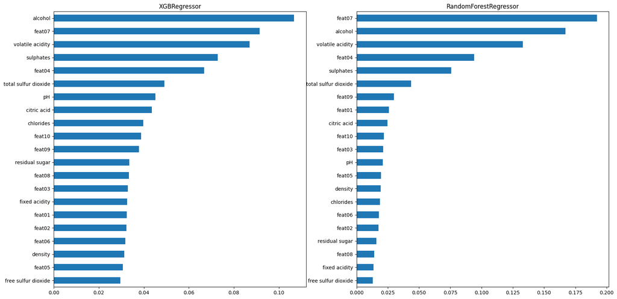

```python
plt.subplots(1, 2, figsize=(20, 10))  # Changed from (2, 2) to (1, 2)
i = 0
model_count = 0
while model_count < 2 and i < len(results.results):
    model = results.results[i].best_model['model']
    if hasattr(model, 'feature_importances_'):
        plt.subplot(1, 2, model_count+1)  # Changed from (2, 2, model_count+1) to (1, 2, model_count+1)
        pd.Series(model.feature_importances_, index=x.columns).groupby(lambda x: x.split('_')[0]).mean().sort_values(ascending=True).plot(kind='barh')
        plt.title(results.results[i].get_model_name())
        model_count += 1
    i += 1
```

### XGBRegressor Feature Importances:

The feature 'alcohol' appears to be the most important one for the XGBRegressor model, followed by 'feat07' and 'volatile acidity'. These features have the longest bars, indicating they have the strongest relationship with the target variable in the model. 'free sulfur dioxide' has the smallest bar, suggesting it is the least important feature in the context of the XGBRegressor's predictions. The synthetic features 'feat01' to 'feat10' vary in importance, with 'feat07' being significant, while others like 'feat05' and 'feat06' are less so.

### RandomForestRegressor Feature Importances:

For the RandomForestRegressor, 'feat07' is the most important feature, followed by 'alcohol' and 'volatile acidity'. This indicates that while both models find 'alcohol' and 'volatile acidity' important, their ordering and relative importance differ. Similarly, 'free sulfur dioxide' is deemed the least important by the RandomForestRegressor. The synthetic features show a different pattern of importance in this model compared to the XGBRegressor, with 'feat04' being more important in the RandomForest model than in the XGBRegressor model.

## Comparative Interpretation:

Both models agree on the high importance of 'alcohol', 'feat07' and 'volatile acidity', which suggests these features likely have a strong and consistent influence on the target variable across different models. The differences in feature importances between the two models can be attributed to the inherent differences in how they learn patterns from the data. XGBRegressor is a gradient boosting model that builds trees sequentially, focusing on errors from the previous tree, while RandomForest builds trees in parallel and averages their predictions. The presence of synthetic features ('featXX') indicates that the data may have been transformed or augmented in some way, and the models find some of these engineered features useful for making predictions.

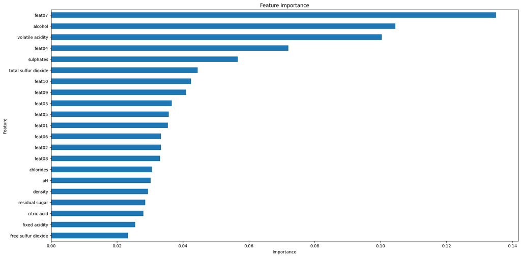

```python
from sklearn.ensemble import RandomForestRegressor

rf = RandomForestRegressor(n_estimators=100, random_state=42)
rf.fit(x, y)
plt.rcParams["figure.figsize"] = [20, 10]
pd.Series(rf.feature_importances_, index=x.columns).groupby(
    lambda x: x.split("_")[0]
).mean().sort_values(ascending=True).plot(
    kind="barh",
    title="Feature Importance",
    xlabel="Importance",
    ylabel="Feature",
)
```

```python
import h2o
h2o.init()
train = h2o.H2OFrame(pd.concat([x, y], axis=1))
test = h2o.H2OFrame(pd.concat([x_out_of_sample, y_out_of_sample], axis=1))
from sklearn.metrics import mean_absolute_error
def oos_predict_with_h2o(model_id, test_frame):
    return mean_absolute_error(test_frame.as_data_frame()['quality'],h2o.get_model(model_id).predict(test_frame).as_data_frame())
```

```
Checking whether there is an H2O instance running at http://localhost:54321. connected.
```

[output not shown]

```
Parse progress: |████████████████████████████████████████████████████████████████| (done) 100%
Parse progress: |████████████████████████████████████████████████████████████████| (done) 100%
```

```python
aml_atp = h2o.automl.H2OAutoML(max_runtime_secs=602, stopping_metric='mae', nfolds=5, sort_metric='mae')
aml_atp.train(x=[col for col in train.columns if col != 'quality'], y='quality', training_frame=train)
lb = aml_atp.leaderboard
```

```
AutoML progress: |███████████████████████████████████████████████████████████████| (done) 100%
```

```python
leaderboard = lb.as_data_frame()
leaderboard['oos_mae'] = leaderboard['model_id'].apply(lambda x: oos_predict_with_h2o(x, test))
leaderboard.sort_values(by='oos_mae')
```

[output not shown]

[output not shown]

[output not shown]

[output not shown]

[output not shown]

[output not shown]

[output not shown]

[output not shown]

[output not shown]

[output not shown]

[output not shown]

[output not shown]

[output not shown]

[output not shown]

[output not shown]

[output not shown]

[output not shown]

[output not shown]

[output not shown]

[output not shown]

[output not shown]

[output not shown]

[output not shown]

[output not shown]

[output not shown]

[output not shown]

[output not shown]

[output not shown]

[output not shown]

[output not shown]

[output not shown]

[output not shown]

[output not shown]

[output not shown]

[output not shown]

[output not shown]

[output not shown]

[output not shown]

[output not shown]

[output not shown]

[output not shown]

[output not shown]

[output not shown]

[output not shown]

[output not shown]

[output not shown]

[output not shown]

[output not shown]

[output not shown]

[output not shown]

[output not shown]

[output not shown]

[output not shown]

[output not shown]

[output not shown]

[output not shown]

|  | model_id | mae | rmse | mse | rmsle | mean_residual_deviance | oos_mae |
| --- | --- | --- | --- | --- | --- | --- | --- |
| 15 | DRF_1_AutoML_1_20240205_95130 | 0.853094 | 1.075555 | 1.156818 | 0.171625 | 1.156818 | 0.871037 |
| 22 | GBM_grid_1_AutoML_1_20240205_95130_model_10 | 0.859609 | 1.073274 | 1.151916 | 0.171354 | 1.151916 | 0.880339 |
| 18 | GBM_grid_1_AutoML_1_20240205_95130_model_8 | 0.853325 | 1.071578 | 1.148279 | 0.170720 | 1.148279 | 0.882094 |
| 35 | GBM_grid_1_AutoML_1_20240205_95130_model_4 | 0.870787 | 1.089472 | 1.186950 | 0.174276 | 1.186950 | 0.890085 |
| 24 | GBM_1_AutoML_1_20240205_95130 | 0.861085 | 1.077017 | 1.159965 | 0.171987 | 1.159965 | 0.892473 |
| ... | ... | ... | ... | ... | ... | ... | ... |
| 65 | DeepLearning_grid_1_AutoML_1_20240205_95130_mo... | 0.908790 | 1.139387 | 1.298204 | 0.181046 | 1.298204 | 1.059351 |
| 77 | DeepLearning_grid_1_AutoML_1_20240205_95130_mo... | 0.931066 | 1.164470 | 1.355990 | 0.183588 | 1.355990 | 1.070313 |
| 85 | DeepLearning_grid_1_AutoML_1_20240205_95130_mo... | 0.981108 | 1.240479 | 1.538787 | 0.201433 | 1.538787 | 1.091728 |
| 80 | DeepLearning_grid_1_AutoML_1_20240205_95130_mo... | 0.946305 | 1.208257 | 1.459885 | 0.189804 | 1.459885 | 1.131711 |
| 86 | DeepLearning_grid_2_AutoML_1_20240205_95130_mo... | 0.982142 | 1.242569 | 1.543977 | 0.196319 | 1.543977 | 1.165936 |

89 rows × 7 columns

```python
leaderboard.sort_values(by='oos_mae')
```

|  | model_id | mae | rmse | mse | rmsle | mean_residual_deviance | oos_mae |
| --- | --- | --- | --- | --- | --- | --- | --- |
| 15 | DRF_1_AutoML_1_20240205_95130 | 0.853094 | 1.075555 | 1.156818 | 0.171625 | 1.156818 | 0.871037 |
| 22 | GBM_grid_1_AutoML_1_20240205_95130_model_10 | 0.859609 | 1.073274 | 1.151916 | 0.171354 | 1.151916 | 0.880339 |
| 18 | GBM_grid_1_AutoML_1_20240205_95130_model_8 | 0.853325 | 1.071578 | 1.148279 | 0.170720 | 1.148279 | 0.882094 |
| 35 | GBM_grid_1_AutoML_1_20240205_95130_model_4 | 0.870787 | 1.089472 | 1.186950 | 0.174276 | 1.186950 | 0.890085 |
| 24 | GBM_1_AutoML_1_20240205_95130 | 0.861085 | 1.077017 | 1.159965 | 0.171987 | 1.159965 | 0.892473 |
| ... | ... | ... | ... | ... | ... | ... | ... |
| 65 | DeepLearning_grid_1_AutoML_1_20240205_95130_mo... | 0.908790 | 1.139387 | 1.298204 | 0.181046 | 1.298204 | 1.059351 |
| 77 | DeepLearning_grid_1_AutoML_1_20240205_95130_mo... | 0.931066 | 1.164470 | 1.355990 | 0.183588 | 1.355990 | 1.070313 |
| 85 | DeepLearning_grid_1_AutoML_1_20240205_95130_mo... | 0.981108 | 1.240479 | 1.538787 | 0.201433 | 1.538787 | 1.091728 |
| 80 | DeepLearning_grid_1_AutoML_1_20240205_95130_mo... | 0.946305 | 1.208257 | 1.459885 | 0.189804 | 1.459885 | 1.131711 |
| 86 | DeepLearning_grid_2_AutoML_1_20240205_95130_mo... | 0.982142 | 1.242569 | 1.543977 | 0.196319 | 1.543977 | 1.165936 |

89 rows × 7 columns

```python
h2o.get_model('DRF_1_AutoML_1_20240205_95130')
```

```
Model Details
=============
H2ORandomForestEstimator : Distributed Random Forest
Model Key: DRF_1_AutoML_1_20240205_95130
```

Model Summary:

|  | number_of_trees | number_of_internal_trees | model_size_in_bytes | min_depth | max_depth | mean_depth | min_leaves | max_leaves | mean_leaves |
| --- | --- | --- | --- | --- | --- | --- | --- | --- | --- |
|  | 29.0 | 29.0 | 258059.0 | 19.0 | 20.0 | 19.896551 | 669.0 | 728.0 | 703.8276 |

```
ModelMetricsRegression: drf
** Reported on train data. **

MSE: 1.227483509200301
RMSE: 1.1079185480892992
MAE: 0.8843097303178773
RMSLE: 0.17660094954603645
Mean Residual Deviance: 1.227483509200301
```

```
ModelMetricsRegression: drf
** Reported on cross-validation data. **

MSE: 1.1568179566502017
RMSE: 1.0755547204350886
MAE: 0.8530938154884747
RMSLE: 0.17162520069144785
Mean Residual Deviance: 1.1568179566502017
```

Cross-Validation Metrics Summary:

|  | mean | sd | cv_1_valid | cv_2_valid | cv_3_valid | cv_4_valid | cv_5_valid |
| --- | --- | --- | --- | --- | --- | --- | --- |
| mae | 0.8563390 | 0.0315365 | 0.8488808 | 0.9095701 | 0.8253728 | 0.8457346 | 0.8521371 |
| mean_residual_deviance | 1.1563162 | 0.1302252 | 1.0668162 | 1.3865879 | 1.1014347 | 1.1063484 | 1.1203938 |
| mse | 1.1563162 | 0.1302252 | 1.0668162 | 1.3865879 | 1.1014347 | 1.1063484 | 1.1203938 |
| r2 | 0.2268569 | 0.0450257 | 0.2407075 | 0.1544548 | 0.2553935 | 0.2684215 | 0.2153070 |
| residual_deviance | 1.1563162 | 0.1302252 | 1.0668162 | 1.3865879 | 1.1014347 | 1.1063484 | 1.1203938 |
| rmse | 1.0740426 | 0.0586174 | 1.0328679 | 1.1775346 | 1.0494926 | 1.051831 | 1.0584866 |
| rmsle | 0.1714271 | 0.0082428 | 0.1632494 | 0.1847680 | 0.1726669 | 0.1697883 | 0.1666628 |

Scoring History:

|  | timestamp | duration | number_of_trees | training_rmse | training_mae | training_deviance |
| --- | --- | --- | --- | --- | --- | --- |
|  | 2024-02-05 09:51:43 | 2.780 sec | 0.0 | nan | nan | nan |
|  | 2024-02-05 09:51:43 | 3.081 sec | 5.0 | 1.3440151 | 1.0679324 | 1.8063766 |
|  | 2024-02-05 09:51:44 | 3.283 sec | 10.0 | 1.2387505 | 0.9893679 | 1.5345028 |
|  | 2024-02-05 09:51:44 | 3.488 sec | 15.0 | 1.1576280 | 0.9227085 | 1.3401026 |
|  | 2024-02-05 09:51:44 | 3.692 sec | 20.0 | 1.1305643 | 0.9042777 | 1.2781756 |
|  | 2024-02-05 09:51:44 | 3.888 sec | 25.0 | 1.1158368 | 0.8945678 | 1.2450918 |
|  | 2024-02-05 09:51:44 | 4.048 sec | 29.0 | 1.1079185 | 0.8843097 | 1.2274835 |

Variable Importances:

| variable | relative_importance | scaled_importance | percentage |
| --- | --- | --- | --- |
| feat07 | 3884.0488281 | 1.0 | 0.1212609 |
| alcohol | 3620.2763672 | 0.9320883 | 0.1130259 |
| volatile acidity | 2553.6252441 | 0.6574648 | 0.0797248 |
| feat04 | 2273.2624512 | 0.5852816 | 0.0709718 |
| sulphates | 2121.6340332 | 0.5462429 | 0.0662379 |
| total sulfur dioxide | 1515.0617676 | 0.3900728 | 0.0473006 |
| pH | 1272.8648682 | 0.3277160 | 0.0397391 |
| citric acid | 1263.0883789 | 0.3251989 | 0.0394339 |
| feat09 | 1200.7572021 | 0.3091509 | 0.0374879 |
| fixed acidity | 1165.9991455 | 0.3002020 | 0.0364028 |
| --- | --- | --- | --- |
| feat01 | 1150.3843994 | 0.2961818 | 0.0359153 |
| feat06 | 1133.7102051 | 0.2918888 | 0.0353947 |
| feat08 | 1112.1553955 | 0.2863392 | 0.0347218 |
| feat05 | 1079.6041260 | 0.2779584 | 0.0337055 |
| feat03 | 1029.0605469 | 0.2649453 | 0.0321275 |
| feat02 | 987.5117798 | 0.2542480 | 0.0308303 |
| free sulfur dioxide | 922.0232544 | 0.2373871 | 0.0287858 |
| residual sugar | 875.6784668 | 0.2254551 | 0.0273389 |
| chlorides | 862.8771362 | 0.2221592 | 0.0269392 |
| density | 847.4989624 | 0.2181999 | 0.0264591 |

```
[21 rows x 4 columns]
```

```
[tips]
Use `model.explain()` to inspect the model.
--
Use `h2o.display.toggle_user_tips()` to switch on/off this section.
```

Best ensembles inspection:

```python
leaderboard[leaderboard['model_id'].astype(str).str.startswith('StackedEnsemble')].sort_values(by='oos_mae')
```

|  | model_id | mae | rmse | mse | rmsle | mean_residual_deviance | oos_mae |
| --- | --- | --- | --- | --- | --- | --- | --- |
| 10 | StackedEnsemble_Best1000_1_AutoML_1_20240205_9... | 0.846831 | 1.059964 | 1.123523 | 0.169178 | 1.123523 | 0.902878 |
| 7 | StackedEnsemble_BestOfFamily_6_AutoML_1_202402... | 0.842812 | 1.057096 | 1.117451 | 0.168368 | 1.117451 | 0.909551 |
| 20 | StackedEnsemble_BestOfFamily_5_AutoML_1_202402... | 0.858041 | 1.091496 | 1.191364 | 0.173724 | 1.191364 | 0.912359 |
| 8 | StackedEnsemble_BestOfFamily_3_AutoML_1_202402... | 0.843766 | 1.057163 | 1.117593 | 0.168284 | 1.117593 | 0.913027 |
| 4 | StackedEnsemble_AllModels_4_AutoML_1_20240205_... | 0.839861 | 1.049905 | 1.102302 | 0.167016 | 1.102302 | 0.914445 |
| 6 | StackedEnsemble_AllModels_3_AutoML_1_20240205_... | 0.841817 | 1.054039 | 1.110999 | 0.167759 | 1.110999 | 0.914484 |
| 1 | StackedEnsemble_AllModels_1_AutoML_1_20240205_... | 0.838802 | 1.051970 | 1.106641 | 0.167551 | 1.106641 | 0.914933 |
| 5 | StackedEnsemble_BestOfFamily_2_AutoML_1_202402... | 0.840870 | 1.054173 | 1.111282 | 0.167699 | 1.111282 | 0.914933 |
| 0 | StackedEnsemble_AllModels_6_AutoML_1_20240205_... | 0.837868 | 1.049488 | 1.101426 | 0.167131 | 1.101426 | 0.915759 |
| 2 | StackedEnsemble_AllModels_2_AutoML_1_20240205_... | 0.839258 | 1.052441 | 1.107633 | 0.167516 | 1.107633 | 0.916597 |
| 3 | StackedEnsemble_BestOfFamily_4_AutoML_1_202402... | 0.839427 | 1.053484 | 1.109830 | 0.167668 | 1.109830 | 0.918045 |
| 9 | StackedEnsemble_BestOfFamily_1_AutoML_1_202402... | 0.844093 | 1.058802 | 1.121061 | 0.168590 | 1.121061 | 0.918871 |
| 44 | StackedEnsemble_AllModels_5_AutoML_1_20240205_... | 0.878885 | 1.100839 | 1.211846 | 0.175234 | 1.211846 | 0.931652 |

```python
h2o.get_model('StackedEnsemble_Best1000_1_AutoML_1_20240205_95130')
```

```
Model Details
=============
H2OStackedEnsembleEstimator : Stacked Ensemble
Model Key: StackedEnsemble_Best1000_1_AutoML_1_20240205_95130
```

Model Summary for Stacked Ensemble:

| key | value |
| --- | --- |
| Stacking strategy | cross_validation |
| Number of base models (used / total) | 21/76 |
| # GBM base models (used / total) | 3/23 |
| # XGBoost base models (used / total) | 5/21 |
| # GLM base models (used / total) | 1/1 |
| # DRF base models (used / total) | 1/2 |
| # DeepLearning base models (used / total) | 11/29 |
| Metalearner algorithm | GLM |
| Metalearner fold assignment scheme | Random |
| Metalearner nfolds | 5 |
| Metalearner fold_column | None |
| Custom metalearner hyperparameters | None |

```
ModelMetricsRegressionGLM: stackedensemble
** Reported on train data. **

MSE: 0.4916434446095879
RMSE: 0.701172906357332
MAE: 0.559950910302537
RMSLE: 0.1142599974858184
Mean Residual Deviance: 0.4916434446095879
R^2: 0.6712287999937206
Null degrees of freedom: 1119
Residual degrees of freedom: 1098
Null deviance: 1674.8445665320614
Residual deviance: 550.6406579627385
AIC: 2429.220599328859
```

```
ModelMetricsRegressionGLM: stackedensemble
** Reported on cross-validation data. **

MSE: 1.1235229575730419
RMSE: 1.0599636586095968
MAE: 0.8468311450521613
RMSLE: 0.16917813642210702
Mean Residual Deviance: 1.1235229575730419
R^2: 0.24867910872029475
Null degrees of freedom: 1119
Residual degrees of freedom: 1098
Null deviance: 1678.92122558586
Residual deviance: 1258.345712481807
AIC: 3354.8678703592027
```

Cross-Validation Metrics Summary:

|  | mean | sd | cv_1_valid | cv_2_valid | cv_3_valid | cv_4_valid | cv_5_valid |
| --- | --- | --- | --- | --- | --- | --- | --- |
| mae | 0.8467946 | 0.0186913 | 0.8245833 | 0.8346310 | 0.8566747 | 0.8724312 | 0.8456527 |
| mean_residual_deviance | 1.123105 | 0.0476455 | 1.0488638 | 1.1014374 | 1.1503971 | 1.157673 | 1.1571538 |
| mse | 1.123105 | 0.0476455 | 1.0488638 | 1.1014374 | 1.1503971 | 1.157673 | 1.1571538 |
| null_deviance | 335.78424 | 28.899176 | 300.62872 | 310.2444 | 367.0188 | 355.14532 | 345.884 |
| r2 | 0.2432456 | 0.0380344 | 0.2314389 | 0.1834482 | 0.2681930 | 0.2800003 | 0.2531474 |
| residual_deviance | 251.66914 | 15.352041 | 226.55457 | 253.3306 | 268.0425 | 252.37271 | 258.04532 |
| rmse | 1.0595726 | 0.0226637 | 1.0241405 | 1.0494939 | 1.0725657 | 1.0759522 | 1.0757109 |
| rmsle | 0.1689391 | 0.0077328 | 0.1561125 | 0.1687441 | 0.1746288 | 0.1753777 | 0.1698322 |

```
[tips]
Use `model.explain()` to inspect the model.
--
Use `h2o.display.toggle_user_tips()` to switch on/off this section.
```

In this section, we have tried out ensemble methods for prediction. We utilized H2O AutoML for the ensemble models building. We have also run AutoML for tree ensembles like XGB and RF to compare them to our pipeline. The best model turned out to be a Random Forest with 29 tress. It's OOS MAE turned out to be a tad bit lower than ours, which is interesting. We could have achieved this model if we were looking for hyperparams long enough, although it is a tradeoff of cost vs performance - marginally better performance for some model that performed better on OOS, but it even might be due to how data was sampled. We additionally inspected ensembled and their performance in this task. It turned out that the best one was a a stacked ensemble of multiple types of models, which utilized a cross-validation stacking strategy with models including 3 GBMs, 5 XGBs, 1 GLM, 1 DRF and 11 DL models. The metalearner was implemented with GLM. We can notice the model was overfit on the training data, though the Cross-Validation performance of the stacked ensemble model is still good, better than some boosting model we have created earlier (not all). Interestingly, the sd in mae was realtively low - only 0,018 across 5 folds, which can promising, as the model did not have a lucky fold that artificially increased its mean score. What's more, running an AutoML instance is just a few lines of code, and in specific cases, the model can outperform our hours of work. It is crucial to understand the drawbacks of this approach, though. In specific cases, the way that we handle the data might be really important, which not all AutoML cases can handle. Depending on our case, we believe that it's always worth running an AutoML instance if you have space for it, since in can become a benchmark for what you will like to achieve. Remember you can always score some points on e.g. feature engineering, implementing some metrics dedicated to your case which solves your business problem the best! Importantly, business expertise is crucial when validating such models and their performance.

## Conclusions:

### Model Performance:

The RandomForestRegressor demonstrated the best performance across both the training data (used in hyperparameter optimization) and the out-of-sample data, showing the lowest mean squared error and root mean squared error. This suggests that it is the most accurate model for this dataset and is likely to generalize well to new, unseen data.

### Feature Importance:

Alcohol and volatile acidity were consistently identified as significant predictors of wine quality by both the XGBRegressor and RandomForestRegressor models, indicating their strong influence on wine quality. Synthetic features varied in their importance between models, with feat07 being notably important in both models, suggesting it captures some underlying pattern that is relevant to predicting wine quality.

### Hyperparameter Optimization:

The use of RandomizedSearchCV for hyperparameter optimization, along with a custom pipeline for preprocessing, enabled efficient and effective tuning of the models. The optimization process was robust due to the use of k-fold cross-validation, ensuring that the hyperparameter tuning was not overfitted to a particular subset of the data.

### Scalability and Extensibility:

The project's structured codebase with data classes for storing hyperparameter optimization results (HyperoptResults) facilitates scalability and extensibility. New models and hyperparameter spaces can be easily added to the hyperparameter optimization process.

### Generalizability:

The RandomForestRegressor's consistent performance suggests that the model is capturing the underlying patterns in the data rather than memorizing the training data, a good sign of its generalizability.

### Leveraging AutoML:

The project's exploration of ensemble methods through H2O AutoML demonstrated the efficacy of automated machine learning in building strong predictive models with minimal manual intervention. The Random Forest model with 29 trees from H2O AutoML achieved a slightly lower out-of-sample mean absolute error than the manually tuned models, highlighting the potential of AutoML to find optimal or near-optimal solutions.  
The best performing ensemble was a stacked ensemble combining different model types, which showed robust cross-validation performance and a low standard deviation in MAE across folds, indicating consistent performance across the dataset. This suggests that AutoML can be a valuable tool for establishing performance benchmarks and potentially saving hours of manual model tuning.  
However, it's important to recognize the limits of AutoML, particularly in data handling and incorporating domain expertise. Custom feature engineering and the application of business-specific metrics remain areas where human input is irreplaceable. AutoML should be viewed as a complementary tool that can augment the data scientist's workflow and serve as a baseline or benchmark for further refinement and validation by domain experts.